CMSC320 Final Project

Group: Julie Young & Alex O'Keeffe

# Predicting Crime at UMD

For our final project we've decided to predict crimes at the University of Maryland, College Park in order to inform UMPD of better police allocation for the next year. Predicting crime hotspots at certain times can help with positioning of police patrols, letting them get to crime scenes faster and, by extension, deter offenders. Faster response times will allow victims to get help quicker and will allow less time for perpetrators to break the law and less time for them to escape.

This will keep campus safer and give students - especially those of them living on campus - peace of mind. Keeping students safe makes UMD a more appealing option for prospective students and allows current students an environment in which they can focus on studying and building their future rather than on having to worry about keeping themselves safe.

Table of Contents:

- Preprocessing
- Exploration
- Comparision
- Predictions
- Conclusion

```python
# below are the key imports for the project

#calculation and data manipulation
import pandas as pd
import numpy as np
import datetime as dt
from datetime import datetime
import re
import tensorflow as tf
import random
from sklearn.model_selection import train_test_split

# graphing
import seaborn as sns
import matplotlib.pyplot as plt
```

# Part 1: Gathering the Data

We decided to grab the on-campus crime data for 2021 and 2022. Below we scrape the data by month from the umpd website and format it into one data frame for each of the years. We also gather data from the safety notices for each year.

Once we gather the data we do an initial formatting of the column names and add a couple columns to the safety dataframes for later. We were able to get all of the months from 2021 but there was no data for July of 2022 or December (likely because it's too early into the month).

```python
# getting the data

# Below we grab the data from each month of the years we're collecting.
# 2022 doesn't have any data for July or December so we skip those.
# We'll also grab the safety notices from each of the years

# 2022
jan = pd.read_html("http://www.umpd.umd.edu/stats/csa_logs.cfm?year=2022&month=1")[0]
feb = pd.read_html("http://www.umpd.umd.edu/stats/csa_logs.cfm?year=2022&month=2")[0]
mar = pd.read_html("http://www.umpd.umd.edu/stats/csa_logs.cfm?year=2022&month=3")[0]
apr = pd.read_html("http://www.umpd.umd.edu/stats/csa_logs.cfm?year=2022&month=4")[0]
may = pd.read_html("http://www.umpd.umd.edu/stats/csa_logs.cfm?year=2022&month=5")[0]
jun = pd.read_html("http://www.umpd.umd.edu/stats/csa_logs.cfm?year=2022&month=6")[0]
aug = pd.read_html("http://www.umpd.umd.edu/stats/csa_logs.cfm?year=2022&month=8")[0]
sep = pd.read_html("http://www.umpd.umd.edu/stats/csa_logs.cfm?year=2022&month=9")[0]
oct = pd.read_html("http://www.umpd.umd.edu/stats/csa_logs.cfm?year=2022&month=10")[0]
nov = pd.read_html("http://www.umpd.umd.edu/stats/csa_logs.cfm?year=2022&month=11")[0]

safety = pd.read_html("http://www.umpd.umd.edu/stats/safety_notices_umpd.cfm?year=22")[0]

# Here we just set up the column names for each of the months and for safety

jan.columns = ["case #", "date time", "report date", "classification", "disposition", "loc"]
feb.columns = ["case #", "date time", "report date", "classification", "disposition", "loc"]
mar.columns = ["case #", "date time", "report date", "classification", "disposition", "loc"]
apr.columns = ["case #", "date time", "report date", "classification", "disposition", "loc"]
may.columns = ["case #", "date time", "report date", "classification", "disposition", "loc"]
jun.columns = ["case #", "date time", "report date", "classification", "disposition", "loc"]
aug.columns = ["case #", "date time", "report date", "classification", "disposition", "loc"]
sep.columns = ["case #", "date time", "report date", "classification", "disposition", "loc"]
oct.columns = ["case #", "date time", "report date", "classification", "disposition", "loc"]
nov.columns = ["case #", "date time", "report date", "classification", "disposition", "loc"]
safety.columns = ["report date", "classification", "case #"]
safety["date time"] = safety["report date"]
safety["disposition"] = np.nan
safety["loc"] = np.nan

#2021

jan21 = pd.read_html("http://www.umpd.umd.edu/stats/csa_logs.cfm?year=2021&month=1")[0]
feb21 = pd.read_html("http://www.umpd.umd.edu/stats/csa_logs.cfm?year=2021&month=2")[0]
mar21 = pd.read_html("http://www.umpd.umd.edu/stats/csa_logs.cfm?year=2021&month=3")[0]
apr21 = pd.read_html("http://www.umpd.umd.edu/stats/csa_logs.cfm?year=2021&month=4")[0]
may21 = pd.read_html("http://www.umpd.umd.edu/stats/csa_logs.cfm?year=2021&month=5")[0]
jun21 = pd.read_html("http://www.umpd.umd.edu/stats/csa_logs.cfm?year=2021&month=6")[0]
jul21 = pd.read_html("http://www.umpd.umd.edu/stats/csa_logs.cfm?year=2021&month=7")[0]
aug21 = pd.read_html("http://www.umpd.umd.edu/stats/csa_logs.cfm?year=2021&month=8")[0]
sep21 = pd.read_html("http://www.umpd.umd.edu/stats/csa_logs.cfm?year=2021&month=9")[0]
oct21 = pd.read_html("http://www.umpd.umd.edu/stats/csa_logs.cfm?year=2021&month=10")[0]
nov21 = pd.read_html("http://www.umpd.umd.edu/stats/csa_logs.cfm?year=2021&month=11")[0]
dec21 = pd.read_html("http://www.umpd.umd.edu/stats/csa_logs.cfm?year=2021&month=12")[0]

# Here we just set up the columns for each of the months and for safety

safety21 = pd.read_html("http://www.umpd.umd.edu/stats/safety_notices_umpd.cfm?year=21")[0]

jan21.columns = ["case #", "date time", "report date", "classification", "disposition", "loc"]
feb21.columns = ["case #", "date time", "report date", "classification", "disposition", "loc"]
mar21.columns = ["case #", "date time", "report date", "classification", "disposition", "loc"]
apr21.columns = ["case #", "date time", "report date", "classification", "disposition", "loc"]
may21.columns = ["case #", "date time", "report date", "classification", "disposition", "loc"]
jun21.columns = ["case #", "date time", "report date", "classification", "disposition", "loc"]
jul21.columns = ["case #", "date time", "report date", "classification", "disposition", "loc"]
aug21.columns = ["case #", "date time", "report date", "classification", "disposition", "loc"]
sep21.columns = ["case #", "date time", "report date", "classification", "disposition", "loc"]
oct21.columns = ["case #", "date time", "report date", "classification", "disposition", "loc"]
nov21.columns = ["case #", "date time", "report date", "classification", "disposition", "loc"]
dec21.columns = ["case #", "date time", "report date", "classification", "disposition", "loc"]
safety21.columns = ["report date", "classification", "case #"]
safety21["date time"] = safety21["report date"]
safety21["disposition"] = np.nan
safety21["loc"] = np.nan
```

Since most of the incidents in the safety notice classifications are separated by "**UPDATE**" in 2022, we separate them then set the locations by hand since there aren't that many points. There are also a few more points that we needed to set manually the disposition and classification.

```python
# We need to remove the "**UPDATE**" from each of the classifications so they're easier to work with
safety["classification"] = safety["classification"].apply(lambda x : x.partition("**UPDATE**")[0])

# Since there are only 9 data points here we manually get the locations and set them in the "loc" column
safety["loc"] = ["Ellicott Hall", "Regents Drive at Campus Drive", \
                 "Annapolis Hall", \
                 "Rudy's Cafe at Van Munching Hall", \
                 "Between Wind Tunnel Building (Paint Branch Drive) & College Park Metro", \
                 "Exterior of School of Public Health Building (4200 Valley Drive)", \
                 "Allegany Hall", \
                 "4300 block of Rowalt Drive", \
                 "Stamp Student Union, Second Floor"]

# Then we clean up a couple more classifications and dispositions manually
safety.loc[0, "classification"] = "Voyeur Incident"
safety.loc[6, "disposition"] = "Unfounded"
safety.loc[7, "classification"] = "Voyeur Incident"
safety.loc[8, "disposition"] = "Unfounded"
safety.head(9)
```

|  | report date | classification | case # | date time | disposition | loc |
| --- | --- | --- | --- | --- | --- | --- |
| 0 | 12/10/22 | Voyeur Incident | 2022-96454 | 12/10/22 | NaN | Ellicott Hall |
| 1 | 11/21/22 | Indecent Exposure | 2022-90037 | 11/21/22 | NaN | Regents Drive at Campus Drive |
| 2 | 10/31/22 | Robbery (No Weapon) | 2022-83336 | 10/31/22 | NaN | Annapolis Hall |
| 3 | 10/05/22 | Indecent Exposure | 2022-74429 | 10/05/22 | NaN | Rudy's Cafe at Van Munching Hall |
| 4 | 09/02/22 | Indecent Exposure | 2022-65091 | 09/02/22 | NaN | Between Wind Tunnel Building (Paint Branch Dri... |
| 5 | 08/22/22 | Indecent Exposure | 2022-61917 | 08/22/22 | NaN | Exterior of School of Public Health Building (... |
| 6 | 04/27/22 | Indecent Exposure | 2022-30126 | 04/27/22 | Unfounded | Allegany Hall |
| 7 | 04/25/22 | Voyeur Incident | 2022-29646 | 04/25/22 | NaN | 4300 block of Rowalt Drive |
| 8 | 04/10/22 | Indecent Exposure | 2022-25416 | 04/10/22 | Unfounded | Stamp Student Union, Second Floor |

For 2021, a similar approach is used to preprocessing, in which we partition the data to get the classification. Then we manually set the location since there are a relatively small number of total data points in the 2021 safety dataframe as well.

```python
# partitions
safety21["classification"] = safety21["classification"].apply(lambda x : x.partition("**UPDATE**")[0])
safety21["classification"] = safety21["classification"].apply(lambda x : x.partition("4200")[0])
safety21["classification"] = safety21["classification"].apply(lambda x : x.partition("(")[0])
safety21["classification"] = safety21["classification"].apply(lambda x : x.partition("Stamp")[0])
safety21["classification"] = safety21["classification"].apply(lambda x : x.partition("The Courtyards")[0])
safety21["classification"] = safety21["classification"].apply(lambda x : x.partition("Parking")[0])
safety21["classification"] = safety21["classification"].apply(lambda x : x.partition("Elkins")[0])

# location setting
safety21["loc"] = ["4200 block of Knox Road and 4500 block of Guilford Road", \
                 "Stamp Student Union", "The Courtyards", \
                 "Cumberland Hall and Bel Air Hall", \
                 "Campus Drive by the Art-Sociology Building", \
                 "The Courtyards", \
                 "University of Maryland", \
                 "Elkins Building (3300 Metzerott Road)", \
                 "Parking Lot 12A (Tulane Drive/Graduate Hills Apartments) & the Parking Lot of the Cypress Building (8320 Baltimore Avenue)", \
                 "3400 block of Tulane Drive", \
                 np.nan, "South Campus Commons #1"]

safety21.head(12)
```

|  | report date | classification | case # | date time | disposition | loc |
| --- | --- | --- | --- | --- | --- | --- |
| 0 | 12/19/21 | Off-Campus Burglaries | PGPD Case Numbers: 21-0059040 and 2112190001933 | 12/19/21 | NaN | 4200 block of Knox Road and 4500 block of Guil... |
| 1 | 12/02/21 | Indecent Exposures | 2021-91147 & 2021-91171 | 12/02/21 | NaN | Stamp Student Union |
| 2 | 10/27/21 | Burglary | 2021-82844 | 10/27/21 | NaN | The Courtyards |
| 3 | 10/17/21 | 4th Degree Burglaries | 2021-80708 and 2021-80709 | 10/17/21 | NaN | Cumberland Hall and Bel Air Hall |
| 4 | 10/01/21 | 4th Degree Sex Offense | 2021-76652 | 10/01/21 | NaN | Campus Drive by the Art-Sociology Building |
| 5 | 09/19/21 | Residential Burglary | 2021-73625 | 09/19/21 | NaN | The Courtyards |
| 6 | 09/05/21 | Multiple Incidents of Fraud | 2021-69323, 2021-75257, 2021-77792, 2021-79267... | 09/05/21 | NaN | University of Maryland |
| 7 | 07/18/21 | Shots Fired | 2021-54556 | 07/18/21 | NaN | Elkins Building (3300 Metzerott Road) |
| 8 | 06/11/21 | Multiple Thefts from Autos | 2021-44989 & 2021-44997 | 06/11/21 | NaN | Parking Lot 12A (Tulane Drive/Graduate Hills A... |
| 9 | 04/15/21 | Multiple Bicycle Thefts3400 block of Tulane Dr... | 2021-31102, 31118, 31128, 31129, 32087, 32136,... | 04/15/21 | NaN | 3400 block of Tulane Drive |
| 10 | 04/01/21 | UMD Advisory - IRS Impersonation ScamNone | None | 04/01/21 | NaN | NaN |
| 11 | 02/05/21 | Burglary | 2021-9617 | 02/05/21 | NaN | South Campus Commons #1 |

The monthly reports are concatenated into one dataframe for each year for further processing to match the processing done on the safety notices. Each of the months' data is formatted the same so they can just be combined into one larger dataframe.

```python
# joining the monthly data into one dataframe per year
data = pd.concat([jan, feb, mar, apr, may, jun, aug, sep, oct], axis = 0)
data21 = pd.concat([jan21, feb21, mar21, apr21, may21, jun21, jul21, aug21, sep21, oct21, nov21, dec21], axis = 0)
```

The web tables stored the locations in the row after each incident so the first loop takes that location and puts it in the same row as the incident. The second loop takes the rows with the incidents and adds them to a new dataframe for each year. After this is done, we concatenate the safety notices to the end of the data frame.

```python
# location getting
for row in data.iterrows():
  if row[1].name % 2 == 0:
    row[1].loc = data.iloc[row[1].name - 1]["loc"]

for row in data21.iterrows():
  if row[1].name % 2 == 0:
    row[1].loc = data21.iloc[row[1].name - 1]["loc"]

# putting the rows with data into new dataframe
crime = pd.DataFrame([], columns = ["case #", "date time", "report date", "classification", "disposition", "loc"])
crime21 = pd.DataFrame([], columns = ["case #", "date time", "report date", "classification", "disposition", "loc"])

for row in data.iterrows():
  if row[1].name % 2 == 0:
    crime.loc[len(crime.index)] = row[1]

for row in data21.iterrows():
  if row[1].name % 2 == 0:
    crime21.loc[len(crime21.index)] = row[1]

# concat safety
crime = pd.concat([crime, safety], axis = 0)
crime = crime.reset_index()

crime21 = pd.concat([crime21, safety21], axis = 0)
crime21 = crime21.reset_index()
```

Since a significant amount of the case number columns are empty and we have no real use for the case numbers, it is dropped along with the extra index column obtained after resetting the index. The index was reset after concatenating the safety notices since they didn't continue from the last index of the crime or crime21 dataframes. Note there are 730 data points in the 2021 dataframe but only 229 in the 2022 dataframe

```python
crime = crime.drop(["case #", "index"], axis = 1) # dropping column with nearly no info
crime.tail(15) # 229 data points
```

|  | date time | report date | classification | disposition | loc |
| --- | --- | --- | --- | --- | --- |
| 214 | 10/29/22 10:15 PM | 12/8/22 | Alcohol Violation | Judicial Referral | Wicomico Hall |
| 215 | 10/30/22 8:30 PM | 12/8/22 | Noise Violation | Judicial Referral | Ellicott Hall |
| 216 | 10/31/22 2:15 AM | 12/8/22 | Noise Violation | Judicial Referral | Ellicott Hall |
| 217 | 10/31/22 8:00 PM | 12/8/22 | Vandalism | Judicial Referral | Pyon-Chen Hall |
| 218 | 10/29/22 1:45 AM | 12/8/22 | Alcohol Violation | Judicial Referral | Worcester Hall |
| 219 | 10/30/22 12:42 AM | 12/8/22 | Alcohol Violation | Judicial Referral | Oakland Hall |
| 220 | 12/10/22 | 12/10/22 | Voyeur Incident | NaN | Ellicott Hall |
| 221 | 11/21/22 | 11/21/22 | Indecent Exposure | NaN | Regents Drive at Campus Drive |
| 222 | 10/31/22 | 10/31/22 | Robbery (No Weapon) | NaN | Annapolis Hall |
| 223 | 10/05/22 | 10/05/22 | Indecent Exposure | NaN | Rudy's Cafe at Van Munching Hall |
| 224 | 09/02/22 | 09/02/22 | Indecent Exposure | NaN | Between Wind Tunnel Building (Paint Branch Dri... |
| 225 | 08/22/22 | 08/22/22 | Indecent Exposure | NaN | Exterior of School of Public Health Building (... |
| 226 | 04/27/22 | 04/27/22 | Indecent Exposure | Unfounded | Allegany Hall |
| 227 | 04/25/22 | 04/25/22 | Voyeur Incident | NaN | 4300 block of Rowalt Drive |
| 228 | 04/10/22 | 04/10/22 | Indecent Exposure | Unfounded | Stamp Student Union, Second Floor |

```python
crime21 = crime21.drop(["case #", "index"], axis = 1) # dropping column with nearly no info
crime21.tail(15) # 730 data points
```

|  | date time | report date | classification | disposition | loc |
| --- | --- | --- | --- | --- | --- |
| 715 | 12/5/21 12:07 AM | 3/15/22 | Vandalism | Judicial Referral | 7400 Blk Dartmouth Avenue |
| 716 | 12/13/21 Unknown | 4/13/22 | Other Incident | Judicial Referral | 4300 Blk Knox Road |
| 717 | 12/2/21 12:50 AM | 6/13/22 | Noise Violation | Judicial Referral | Ellicott Hall |
| 718 | 12/19/21 | 12/19/21 | Off-Campus Burglaries | NaN | 4200 block of Knox Road and 4500 block of Guil... |
| 719 | 12/02/21 | 12/02/21 | Indecent Exposures | NaN | Stamp Student Union |
| 720 | 10/27/21 | 10/27/21 | Burglary | NaN | The Courtyards |
| 721 | 10/17/21 | 10/17/21 | 4th Degree Burglaries | NaN | Cumberland Hall and Bel Air Hall |
| 722 | 10/01/21 | 10/01/21 | 4th Degree Sex Offense | NaN | Campus Drive by the Art-Sociology Building |
| 723 | 09/19/21 | 09/19/21 | Residential Burglary | NaN | The Courtyards |
| 724 | 09/05/21 | 09/05/21 | Multiple Incidents of Fraud | NaN | University of Maryland |
| 725 | 07/18/21 | 07/18/21 | Shots Fired | NaN | Elkins Building (3300 Metzerott Road) |
| 726 | 06/11/21 | 06/11/21 | Multiple Thefts from Autos | NaN | Parking Lot 12A (Tulane Drive/Graduate Hills A... |
| 727 | 04/15/21 | 04/15/21 | Multiple Bicycle Thefts3400 block of Tulane Dr... | NaN | 3400 block of Tulane Drive |
| 728 | 04/01/21 | 04/01/21 | UMD Advisory - IRS Impersonation ScamNone | NaN | NaN |
| 729 | 02/05/21 | 02/05/21 | Burglary | NaN | South Campus Commons #1 |

Many of the incidents in the 2021 data had similar names such that they could be encapsulated by another category. For example different classifications involving fraud all had their classifications redefined as simply fraud. Combining these classifications into a broader one makes the analysis simpler since we have less specific classifications to worry about, which then helps generalize our results. We went ahead and manually combined the classifications by searching for key terms in the more specific classifications.

```python
# reducing number of duplicate incidents (since reiterated)

for row in crime21.iterrows():
  if "Theft" in row[1].classification:
    row[1].classification = "Theft"
  elif "Weapon" in row[1].classification:
    row[1].classification = "Weapon Law Violation"
  elif "Assault" in row[1].classification:
    row[1].classification = "Assault"
  elif "Vandalism" in row[1].classification:
    row[1].classification = "Vandalism"
  elif "Fraud" in row[1].classification or "Scam" in row[1].classification or "Counterfeit" in row[1].classification:
    row[1].classification = "Fraud"
  elif "Rape" in row[1].classification:
    row[1].classification = "Rape"
  elif "Fondling" in row[1].classification:
    row[1].classification = "Fondling"
  elif "Trespassing" in row[1].classification:
    row[1].classification = "Trespassing"
  elif "Hate" in row[1].classification:
    row[1].classification = "Hate Bias Incident"
  elif "Burglar" in row[1].classification:
    row[1].classification = "Burglary"
  elif "Stole" in row[1].classification:
    row[1].classification = "Theft"
  elif "Drug" in row[1].classification:
    row[1].classification = "Drug/Narcotic Violation"
  elif "Driving Under Influence" in row[1].classification:
    row[1].classification = "Driving Under Influence"
  elif "Other" in row[1].classification:
    row[1].classification = "Other"
  elif "Peeping" in row[1].classification:
    row[1].classification = "Voyeur Incident"

crime21["classification"].unique()
```

```
array(['Noise Violation', 'Alcohol Violation', 'Vandalism', 'Theft',
       'Rape', 'Indecent Exposure', 'Harassment', 'Burglary', 'Fraud',
       'Assault', 'Trespassing', 'Disorderly Conduct',
       'Police Information/ Investigation', 'Dating Violence', 'Fondling',
       'Stalking', 'Death', 'Robbery', 'Other', 'Arson',
       'Hate Bias Incident', 'Drug/Narcotic Violation', 'Trash Dumping',
       'Weapon Law Violation', 'Driving Under Influence',
       'Voyeur Incident', 'Suspicious Activity',
       'Online/Telephone Misuse', 'Check on Welfare', 'False Alarm',
       'Embezzlement', 'Indecent Exposures', '4th Degree Sex Offense ',
       'Shots Fired'], dtype=object)
```

All of the time and date related columns are parsed using regular expressions to get an array of values to be parsed in datetime constructors. We also created dummy columns for the date and time of the crime and the date of the report so that we could better test our operations without risk of losing data during parsing in case the parsing was incorrect.

```python
# parsing the dates and times

crime["date_time"] = crime["date time"].apply(lambda x : re.split("^(\d+)\/(\d+)\/(\d+)( (\d+):(\d+)\s*(AM|PM|am|pm)| (Unknown)| (Evening)|)$", x))
crime["report_date"] = crime["report date"].apply(lambda x : re.split("^(\d+)\/(\d+)\/(\d+)$", x))

crime21["date_time"] = crime21["date time"].apply(lambda x : re.split("^(\d+)\/(\d+)\/(\d+)( (\d+):(\d+)\s*(AM|PM|am|pm)| (Unknown)| (Evening)|)$", x))
crime21["report_date"] = crime21["report date"].apply(lambda x : re.split("^(\d+)\/(\d+)\/(\d+)$", x))
```

```python
# establishing dummy columns for preprocessing

crime["date"] = crime.index
crime["time"] = crime.index
crime["report"] = crime.index
crime.head()

crime21["date"] = crime21.index
crime21["time"] = crime21.index
crime21["report"] = crime21.index
crime21.head()
```

|  | date time | report date | classification | disposition | loc | date_time | report_date | date | time | report |
| --- | --- | --- | --- | --- | --- | --- | --- | --- | --- | --- |
| 0 | 1/29/21 12:23 AM | 2/9/21 | Noise Violation | Judicial Referral | Centreville Hall | [, 1, 29, 21, 12:23 AM, 12, 23, AM, None, Non... | [, 2, 9, 21, ] | 0 | 0 | 0 |
| 1 | 1/30/21 1:30 AM | 2/9/21 | Noise Violation | Judicial Referral | Allegany Hall | [, 1, 30, 21, 1:30 AM, 1, 30, AM, None, None, ] | [, 2, 9, 21, ] | 1 | 1 | 1 |
| 2 | 1/27/21 12:15 AM | 2/9/21 | Noise Violation | Judicial Referral | Allegany Hall | [, 1, 27, 21, 12:15 AM, 12, 15, AM, None, Non... | [, 2, 9, 21, ] | 2 | 2 | 2 |
| 3 | 1/24/21 12:15 AM | 2/9/21 | Noise Violation | Judicial Referral | Calvert Hall | [, 1, 24, 21, 12:15 AM, 12, 15, AM, None, Non... | [, 2, 9, 21, ] | 3 | 3 | 3 |
| 4 | 1/24/21 12:30 AM | 2/9/21 | Alcohol Violation | Judicial Referral | Elkton Hall | [, 1, 24, 21, 12:30 AM, 12, 30, AM, None, Non... | [, 2, 9, 21, ] | 4 | 4 | 4 |

The first loop here iterates over the 2022 data and takes the arrays from the regex and uses the appropriate index to create datetime.date and datetime.time objects instead of strings. This will make it easier to work with the data so we can extract a specific date or time instead of having to work with more regex or converting strings to ints. The second loop does the same process for the 2021 data.

```python
# getting date, time and report time into the new columns

for row in crime.iterrows():
  if row[1].date_time[0] == '':
    crime.loc[row[1].name, "date"] = dt.date((2022), int(row[1].date_time[1]), int(row[1].date_time[2]))
  else:
    crime.loc[row[1].name, "date"] = np.nan

  if len(row[1].date_time) > 1 and row[1].date_time[5] is not None:
    crime.loc[row[1].name, "time"] = dt.time(int(row[1].date_time[5]), int(row[1].date_time[6]), 0)
  else:
    crime.loc[row[1].name, "time"] = np.nan

  crime.loc[row[1].name, "report"] = dt.date((2022), int(row[1].report_date[1]), int(row[1].report_date[2]))

for row in crime21.iterrows():
  if row[1].date_time[0] == '':
    crime21.loc[row[1].name, "date"] = dt.date((2021), int(row[1].date_time[1]), int(row[1].date_time[2]))
  else:
    crime21.loc[row[1].name, "date"] = np.nan

  if len(row[1].date_time) > 1 and len(row[1].date_time) > 6 and row[1].date_time[5] is not None and row[1].date_time[5].isnumeric():
    crime21.loc[row[1].name, "time"] = dt.time(int(row[1].date_time[5]), int(row[1].date_time[6]), 0)
  else:
    crime21.loc[row[1].name, "time"] = np.nan

  if row[1].report_date[1].isnumeric() and row[1].report_date[2].isnumeric():
    crime21.loc[row[1].name, "report"] = dt.date((2021), int(row[1].report_date[1]), int(row[1].report_date[2]))
```

We ended up with columns from the preprocessing that we won't need in our analysis so we decided to just drop them from both of the dataframes

```python
# dropping old columns from preprocessing

crime = crime.drop(["date time", "report date", "date_time", "report_date"], axis = 1)
crime.head()
```

|  | classification | disposition | loc | date | time | report |
| --- | --- | --- | --- | --- | --- | --- |
| 0 | Noise Violation | Judicial Referral | The Courtyards Apartments | 2022-01-26 | 10:45:00 | 2022-02-15 |
| 1 | Vandalism | Judicial Referral | Caroline Hall | 2022-01-30 | 08:00:00 | 2022-02-15 |
| 2 | Vandalism | Judicial Referral | Denton Hall | 2022-01-29 | 12:15:00 | 2022-02-15 |
| 3 | Vandalism | Judicial Referral | Elkton Hall | 2022-01-29 | 12:15:00 | 2022-02-15 |
| 4 | Vandalism | Judicial Referral | Elkton Hall | 2022-01-29 | 10:35:00 | 2022-02-15 |

```python
crime21 = crime21.drop(["date time", "report date", "date_time", "report_date"], axis = 1)
crime21.head()
```

|  | classification | disposition | loc | date | time | report |
| --- | --- | --- | --- | --- | --- | --- |
| 0 | Noise Violation | Judicial Referral | Centreville Hall | 2021-01-29 | 12:23:00 | 2021-02-09 |
| 1 | Noise Violation | Judicial Referral | Allegany Hall | 2021-01-30 | 01:30:00 | 2021-02-09 |
| 2 | Noise Violation | Judicial Referral | Allegany Hall | 2021-01-27 | 12:15:00 | 2021-02-09 |
| 3 | Noise Violation | Judicial Referral | Calvert Hall | 2021-01-24 | 12:15:00 | 2021-02-09 |
| 4 | Alcohol Violation | Judicial Referral | Elkton Hall | 2021-01-24 | 12:30:00 | 2021-02-09 |

We made some initial graphs to look at the different frequencies in the data and see how crime in 2021 compares to crime in 2022. The graphs below show the count of each of the classifications of crime for each of the years. From this we can see that noise violations and vandalism are very prominent crimes across both years whereas theft was much more common in 2021 than 2022.

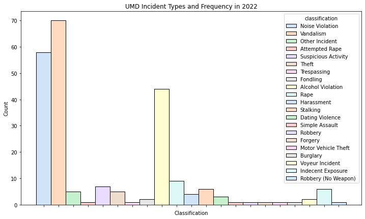

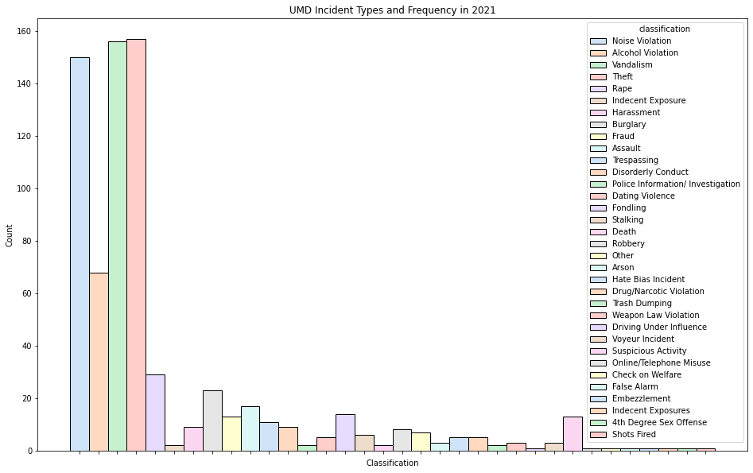

```python
#plotting frequency of incidents

#2022
plt.figure(figsize=(12, 7))
sns.histplot(data = crime, x = "classification", hue = "classification", palette = "pastel")

frame1 = plt.gca()
frame1.axes.xaxis.set_ticklabels([])

plt.xlabel("Classification")
plt.title("UMD Incident Types and Frequency in 2022")

#2021
plt.figure(figsize=(16, 10))
sns.histplot(data = crime21, x = "classification", hue = "classification", palette = "pastel")

plt.xlabel("Classification")
plt.title("UMD Incident Types and Frequency in 2021")

frame1 = plt.gca()
frame1.axes.xaxis.set_ticklabels([])

plt.show()
```

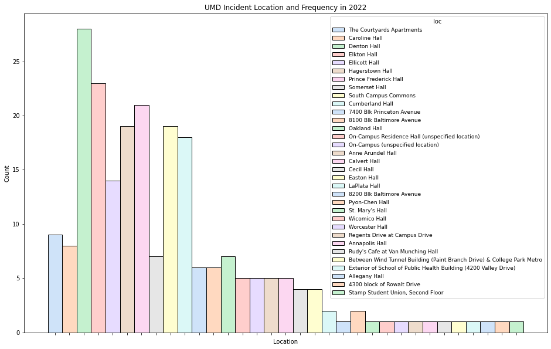

[figure not shown]

```python
# plotting frequency of locations with incidents

plt.figure(figsize=(16, 10))
sns.histplot(data = crime, x = "loc", hue = "loc", palette = "pastel")

frame1 = plt.gca()
frame1.axes.xaxis.set_ticklabels([])
plt.setp(frame1.get_legend().get_title(), fontsize='10')
plt.setp(frame1.get_legend().get_texts(), fontsize='9')
plt.xlabel("Location")
plt.title("UMD Incident Location and Frequency in 2022")

plt.figure(figsize=(19, 10))
sns.histplot(data = crime21, x = "loc", hue = "loc", palette = "pastel")

frame1 = plt.gca()
frame1.tick_params(axis='x', rotation=90)
plt.legend([],[], frameon=False)
plt.xlabel("Location")
plt.title("UMD Incident Location and Frequency in 2021")

plt.show()
```

Due to speculation on campus regarding the number and frequency of indecent exposures, we decided to look at a graph of the different locations of indecent exposures around campus and concluded that the number was not significant. There seems to be no trend in location and there are only eight counts total across both years.

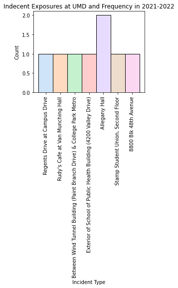

```python
# plotting indecent exposure locations

i_ex = pd.concat([crime[crime["classification"] == "Indecent Exposure "], crime21[crime21["classification"] == "Indecent Exposure"]], axis = 0)

plt.figure(figsize=(4, 3))
sns.histplot(data = i_ex, x = "loc", hue = "loc", palette = "pastel")

frame1 = plt.gca()
frame1.tick_params(axis='x', rotation=90)
plt.legend([],[], frameon=False)
plt.xlabel("Incident Type")
plt.title("Indecent Exposures at UMD and Frequency in 2021-2022")
```

After visualizing the number of crimes recorded by a couple variables (classification and location) we wanted to start seeing how different variables interacted. We began thinking of what plots we could use to make meaningful conclusions and what variables we had that would be useful to compare. Our first graph compares the classification of each crime to the month in which it was committed. Without much technical analysis there doesn't seem to be too much correlation between classification and date, although it is interesting to see a drop in overall crime from around may to late august of 2022.

Taking a bit of a closer look at the grapph it does seem like indecent exposures are more common during the UMD fall semester, while dating violence, stalking, theft, and harassment are all more common during the spring semester.

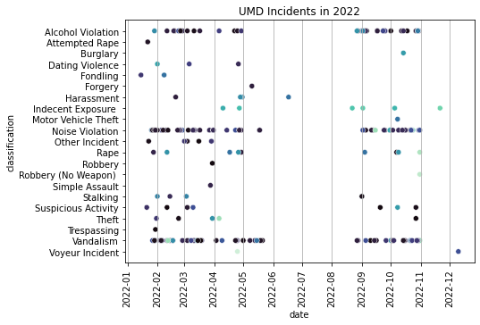

```python
# plotting incident over time for 2022
plt.figure(figsize=(7, 5))

sns.scatterplot(data=crime.sort_values("classification"), y="classification", x="date", hue="loc", palette="mako")

frame1 = plt.gca()
frame1.tick_params(axis='x', rotation=90)
plt.legend([],[], frameon=False)
plt.grid(axis="x")
#plt.xlabel("Incident Type")
plt.title("UMD Incidents in 2022")
```

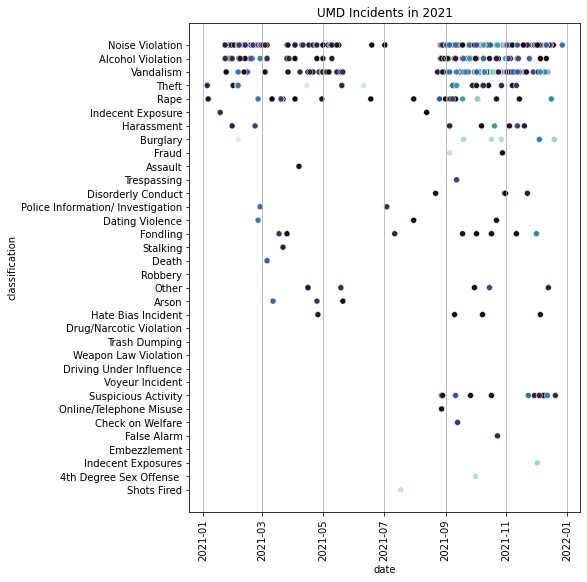

```python
# plotting incidents over time in 2021
plt.figure(figsize=(7, 9))

sns.scatterplot(data=crime21, y="classification", x="date", hue="loc", palette="mako")

frame1 = plt.gca()
frame1.tick_params(axis='x', rotation=90)
plt.legend([],[], frameon=False)
plt.grid(axis="x")
#plt.xlabel("Incident Type")
plt.title("UMD Incidents in 2021")
```

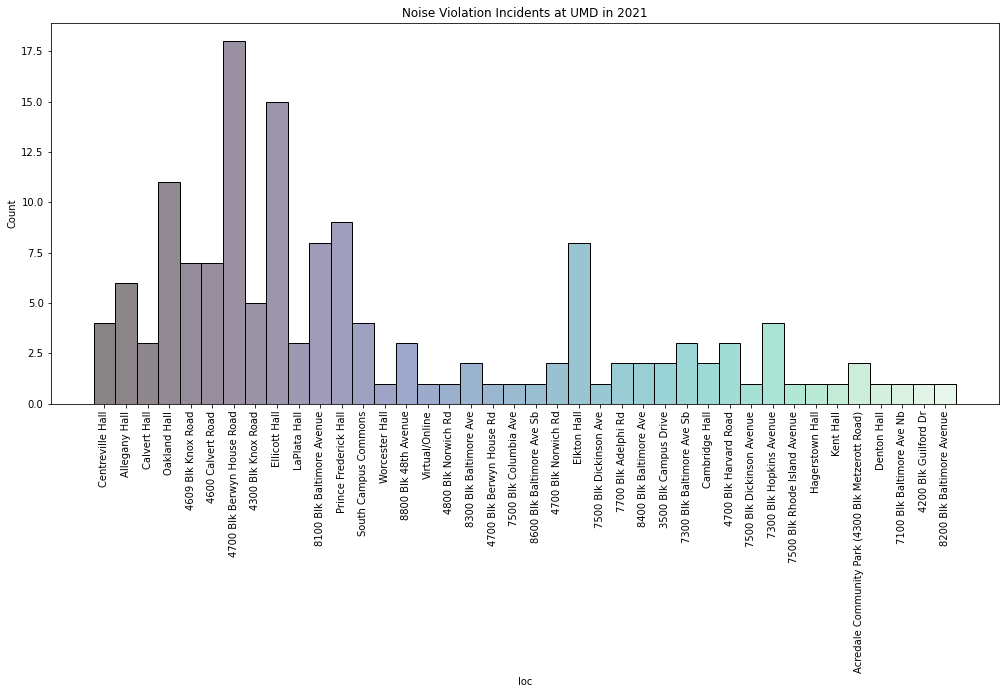

```python
# plotting noise violation incidents in 2021
plt.figure(figsize=(17, 7))
sns.histplot(data=crime21[crime21["classification"] == "Noise Violation"], x = "loc", hue = "loc", palette="mako")

frame1 = plt.gca()
frame1.tick_params(axis='x', rotation=90)
plt.legend([],[], frameon=False)
plt.title("Noise Violation Incidents at UMD in 2021")
```

```python
# plotting theft incidents in 2021
plt.figure(figsize=(17, 7))
sns.histplot(data=crime21[crime21["classification"] == "Theft"], x = "loc", hue = "loc", palette="mako")

frame1 = plt.gca()
frame1.tick_params(axis='x', rotation=90)
plt.legend([],[], frameon=False)
plt.title("Theft Incidents at UMD in 2021")
```

[output not shown]

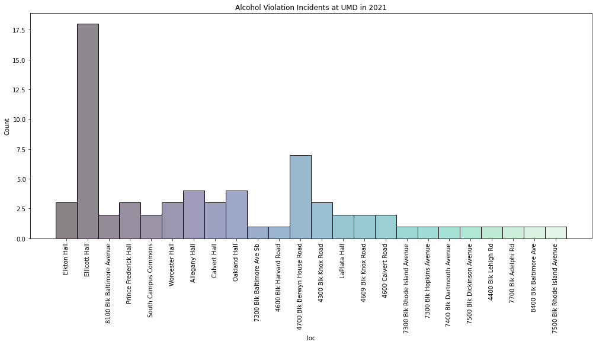

```python
# plotting alcohol violation incidents in 2021
plt.figure(figsize=(17, 7))
sns.histplot(data=crime21[crime21["classification"] == "Alcohol Violation"], x = "loc", hue = "loc", palette="mako")

frame1 = plt.gca()
frame1.tick_params(axis='x', rotation=90)
plt.legend([],[], frameon=False)
plt.title("Alcohol Violation Incidents at UMD in 2021")
```

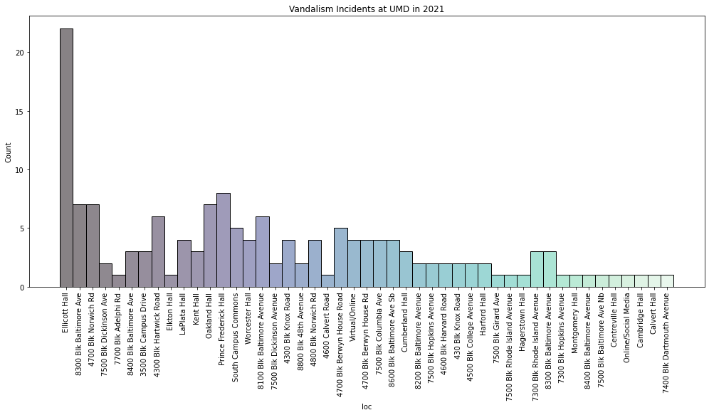

```python
# plotting vandalism incidents in 2021
plt.figure(figsize=(17, 7))
sns.histplot(data=crime21[crime21["classification"] == "Vandalism"], x = "loc", hue = "loc", palette="mako")

frame1 = plt.gca()
frame1.tick_params(axis='x', rotation=90)
plt.legend([],[], frameon=False)
plt.title("Vandalism Incidents at UMD in 2021")
```

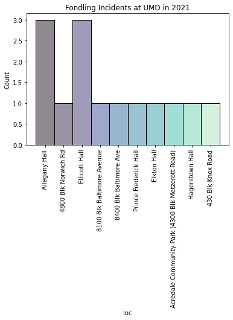

```python
# plotting fondling incidents in 2021

sns.histplot(data=crime21[crime21["classification"] == "Fondling"], x = "loc", hue = "loc", palette="mako")

frame1 = plt.gca()
frame1.tick_params(axis='x', rotation=90)
plt.legend([],[], frameon=False)
plt.title("Fondling Incidents at UMD in 2021")
```

# Neural Network

In order to classify what crimes will appear in 2023 we attempted to use a Neural Network to go through the data. To set up the data we take the classifications of the crimes as the target data andn format the report/date/time to be more understandable for the algorithm.

```python
random.seed(20)

copy = pd.concat([crime21, crime], axis = 0)
combined = copy
y_train = pd.get_dummies(copy["classification"])

copy["report"] = copy["report"].apply(lambda x : 10000*x.year + 100*x.month + x.day)
copy["date"] = copy["date"].apply(lambda x : 10000*x.year + 100*x.month + x.day if isinstance(x, dt.date) else 0)
copy["time"] = copy["time"].apply(lambda x : 60*x.hour + x.minute if isinstance(x, dt.time) else 0)

copy = copy.drop(["classification", "disposition"], axis=1)
copy = pd.get_dummies(copy, columns=["loc"])

x_train, x_test, y_train, y_test = train_test_split(copy, y_train, test_size=.2)
```

```python
copy.shape
```

```
(959, 96)
```

```python
model = tf.keras.models.Sequential([
  #tf.keras.layers.Normalization(axis=-1), #Normalization layer
  tf.keras.layers.Dense(959, input_dim=96, activation='tanh', kernel_initializer='he_uniform'), # Number of input features
  tf.keras.layers.Dense(700, activation='softmax'),
  tf.keras.layers.Dense(497, activation='softmax'),
  tf.keras.layers.Dense(41, activation='softmax') # Number of Output classes
])

model.compile(loss='categorical_crossentropy', optimizer=tf.keras.optimizers.SGD(learning_rate=0.01, momentum=0.9), metrics=['accuracy'])
model.fit(x_train, y_train, epochs=10)
```

```
<keras.callbacks.History at 0x7f2a927a5d00>
```

```python
# testing the model

results, acc = model.evaluate(x_test,  y_test)
results2, acc = model.evaluate(x_train, y_train)
print(f'Average Testing error: {results/len(x_test)}')
print(f'Average Training error: {results2/len(x_train)}')
```

```
Average Testing error: 0.012674849480390549
Average Training error: 0.003339704354396855
```

```python
# getting nn predictions

prediction = model.predict(copy)

# get index for max probability for the "classification"
index = prediction.argmax(axis=1).tolist()
# find the corresponding classification
classes = combined["classification"].unique()
# set that as the row value
for elt in range(len(index)):
  index[elt] = classes[index[elt]]

# len(index)
combined['nn_prediction'] = index
```

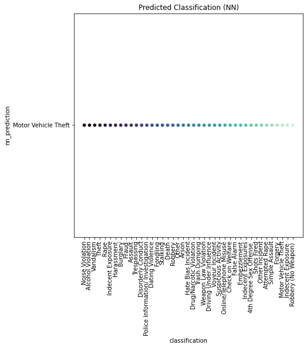

```python
# should be a diagonalish plot

plt.figure(figsize=(7, 7))
sns.scatterplot(data=combined, x="classification", y="nn_prediction", hue="classification", palette="mako")
plt.title("Predicted Classification (NN)")

frame1 = plt.gca()
frame1.tick_params(axis='x', rotation=90)
plt.legend([],[], frameon=False)
plt.show()
```

# Arima

We came across a model called ARIMA while looking for something to analyze a time series to possibly predict when crimes would occur. the first stat to using it is to look at the autocorrelation of the time data across both of the years. We first look at a series of graphs to determine specific parameters we need to actually implement the model.

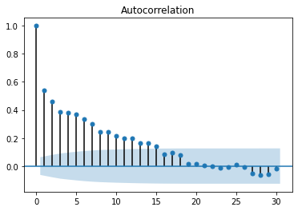

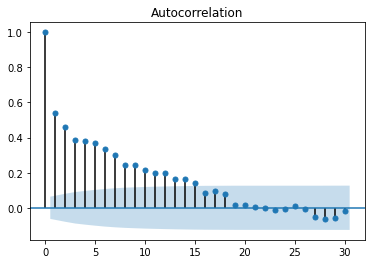

```python
# ARIMA https://www.projectpro.io/article/how-to-build-arima-model-in-python/544#mcetoc_1fp23v670h
#temp = copy.sort_values('report')
#temp = temp['report']
temp = copy.time
# trying to find the d value so we're plotting autocorrelation for report date
from statsmodels.graphics.tsaplots import plot_acf
plot_acf(temp)
```

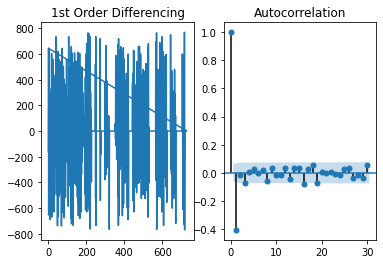

```python
# taking the 1st order difference because our graph was eh
f = plt.figure()
ax1 = f.add_subplot(121)
ax1.set_title('1st Order Differencing')
ax1.plot(temp.diff())

ax2 = f.add_subplot(122)
plot_acf(temp.diff().dropna(), ax=ax2)
plt.show()
```

We used the Augmented Dickey-Fuler test to determine which differential to use in the model (0, 1st, or 2nd). The aim is to use the test with a p-value below our desired threshold while still being closest to it. In other words it's ok for a test to be above the desired p-value as long as it is closer than the other tests. Out of all the p-values we had we decided the best would be the 3.85e-10 so we decided on using the 0th differential.

```python
# Augmented Dickey-Fuller test

from statsmodels.tsa.stattools import adfuller
#normal
result = adfuller(temp.dropna())
print('p-value: ', result[1])

# 1st diff
result = adfuller(temp.diff().dropna())
print('p-value: ', result[1])

# 2nd diff
result = adfuller(temp.diff().diff().dropna())
print('p-value: ', result[1])
```

```
p-value:  3.8547425526127595e-10
p-value:  3.2293603253260657e-24
p-value:  1.5619423523232244e-23
```

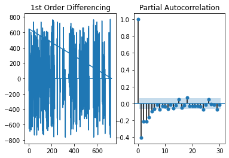

```python
from statsmodels.graphics.tsaplots import plot_pacf

f = plt.figure()
ax1 = f.add_subplot(121)
ax1.set_title('1st Order Differencing')
ax1.plot(temp.diff())

ax2 = f.add_subplot(122)
plot_pacf(temp.diff().dropna(), ax=ax2)
plt.show()
```

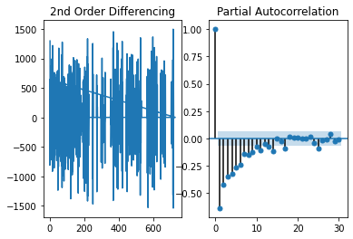

```python
f = plt.figure()
ax1 = f.add_subplot(121)
ax1.set_title('2nd Order Differencing')
ax1.plot(temp.diff().diff())

ax2 = f.add_subplot(122)
plot_pacf(temp.diff().diff().dropna(), ax=ax2)
plt.show()
```

The originall parameters we came up with for using with the ARIMA model were p = 1, d = 1, and q = 1, although using those parameters caused an error in the model We did get the model to work after altering the values but we later decided to go back and slightly change the format of our data which resulted in different graphs and different p-values. From these new values we decided to use (1, 0, 2) as our input values for "order"

```python
# ARIMA(p = 1, d = 1, q = 1)

from statsmodels.tsa.arima_model import ARIMA

arima_model = ARIMA(temp.dropna(), order=(1,0,2))
model = arima_model.fit()
print(model.summary())
```

```
                              ARMA Model Results
==============================================================================
Dep. Variable:                   time   No. Observations:                  959
Model:                     ARMA(1, 2)   Log Likelihood               -6622.284
Method:                       css-mle   S.D. of innovations            241.326
Date:                Sat, 17 Dec 2022   AIC                          13254.568
Time:                        02:58:53   BIC                          13278.897
Sample:                             0   HQIC                         13263.834

==============================================================================
                 coef    std err          z      P>|z|      [0.025      0.975]
------------------------------------------------------------------------------
const        309.1095     34.992      8.834      0.000     240.527     377.692
ar.L1.time     0.9179      0.021     44.183      0.000       0.877       0.959
ma.L1.time    -0.5602      0.039    -14.508      0.000      -0.636      -0.485
ma.L2.time    -0.0674      0.033     -2.029      0.042      -0.133      -0.002
                                    Roots
=============================================================================
                  Real          Imaginary           Modulus         Frequency
-----------------------------------------------------------------------------
AR.1            1.0895           +0.0000j            1.0895            0.0000
MA.1            1.5105           +0.0000j            1.5105            0.0000
MA.2           -9.8172           +0.0000j            9.8172            0.5000
-----------------------------------------------------------------------------
```

Below we have the time series (in blue) overlayed onto the actual values we have for time. The times we found were a little non-uniform but the model does a pretty good job of estimating them regardless.

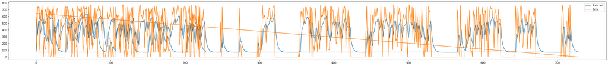

```python
fig = plt.figure()
fig = model.plot_predict(dynamic=False)
fig.set_size_inches(40, 4)
```

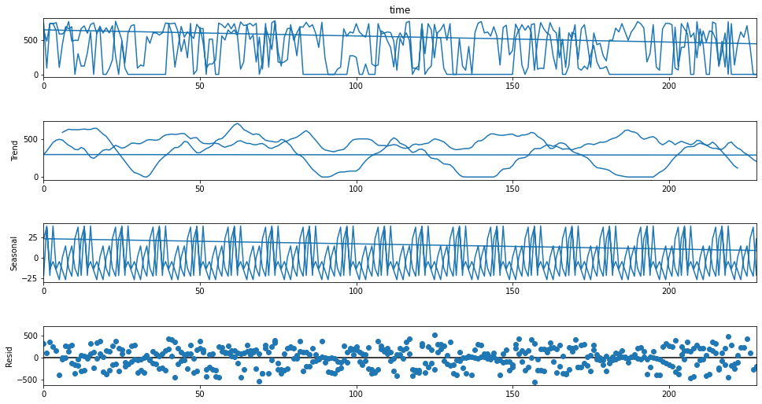

```python
# Seasonal Arima
from statsmodels.tsa.seasonal import seasonal_decompose
decomposition = seasonal_decompose(temp.dropna(), freq=12)
fig = plt.figure()
fig = decomposition.plot()
fig.set_size_inches(15, 8)
```

# Conclusion

Here is our main takeaway from this data:

1 - The most common crimes are Vandalism, Noise Violation, and Alcohol Violation across both years, with Theft being very common only in 2021

According to our results, it appears that since the incidents occur mainly in the north of campus nearer to the Denton Quad, it would be beneficial for campus police to patrol closer to that part of campus and be ready to head there more than other areas on campus. This will lower response times and help to keep the campus safer.